# Report on Expungement Outcomes in the Virginia Court Data

## How many records qualify as automatic, automatic (pending), petition, petition (pending), or not expungable, in every by year in the data?

[output not shown]

First we extract year from the `HearingDate` column:

```python
courtdata['year'] = pd.DatetimeIndex(pd.to_datetime(courtdata['HearingDate'], errors='coerce')).year
```

There were several errors in how hearing date was entered into the data, with some nonsensical, future years:

```python
courtdata.year.value_counts()
```

```
2009.0    813349
2010.0    789518
2011.0    779835
2012.0    760602
2013.0    743072
2014.0    718450
2015.0    679561
2017.0    668354
2019.0    666773
2018.0    662967
2016.0    654794
2007.0    134757
2008.0    133051
2006.0    127121
2004.0    120752
2002.0    120492
2003.0    119054
2005.0    117721
2001.0    117505
2000.0    111797
2020.0     13227
2021.0       751
2022.0       261
2023.0       108
2024.0        78
2028.0        59
2025.0        58
2026.0        36
2029.0        29
2027.0        26
2031.0        14
2030.0        14
2033.0        11
2048.0         6
2040.0         6
2037.0         4
2045.0         4
2041.0         4
2044.0         4
2042.0         3
2065.0         3
2052.0         3
2058.0         3
2060.0         3
2038.0         3
2035.0         2
2049.0         2
2047.0         2
2034.0         2
2054.0         2
2032.0         2
2050.0         2
2043.0         2
2036.0         1
2051.0         1
2059.0         1
2062.0         1
2039.0         1
2055.0         1
Name: year, dtype: int64
```

We replace these future years with missing values for now, until we can dig into the data to see what went wrong with these codes:

```python
courtdata.year[courtdata.year > 2020] = np.nan
```

The following table lists **raw counts** of each expungability outcome by year:

```python
pd.crosstab(courtdata.year, courtdata.expungable)
```

| expungable year | Automatic | Automatic (pending) | Not eligible | Petition | Petition (pending) |
| --- | --- | --- | --- | --- | --- |
| 2000.0 | 13633 | 0 | 61602 | 36562 | 0 |
| 2001.0 | 12768 | 0 | 68663 | 36074 | 0 |
| 2002.0 | 11919 | 0 | 73100 | 35473 | 0 |
| 2003.0 | 10752 | 0 | 75154 | 33148 | 0 |
| 2004.0 | 8397 | 0 | 80403 | 31952 | 0 |
| 2005.0 | 7381 | 0 | 78876 | 31464 | 0 |
| 2006.0 | 7039 | 0 | 87114 | 32968 | 0 |
| 2007.0 | 7937 | 0 | 92179 | 34641 | 0 |
| 2008.0 | 6933 | 0 | 93220 | 32898 | 0 |
| 2009.0 | 241992 | 0 | 402583 | 168774 | 0 |
| 2010.0 | 228820 | 0 | 412903 | 147795 | 0 |
| 2011.0 | 226272 | 0 | 416232 | 127132 | 10199 |
| 2012.0 | 217066 | 0 | 418471 | 115079 | 9986 |
| 2013.0 | 209801 | 0 | 416822 | 106310 | 10139 |
| 2014.0 | 44211 | 170575 | 389841 | 91698 | 22125 |
| 2015.0 | 43395 | 166443 | 362852 | 85410 | 21461 |
| 2016.0 | 44051 | 162160 | 348354 | 80016 | 20213 |
| 2017.0 | 42513 | 173038 | 352786 | 77613 | 22404 |
| 2018.0 | 42147 | 177121 | 345373 | 74237 | 24089 |
| 2019.0 | 44868 | 190851 | 332028 | 71499 | 27527 |
| 2020.0 | 501 | 2436 | 8202 | 921 | 1167 |

And this table lists **the row percents** -- out of all records in each year, what percent falls within each expungability outcome?

```python
rowtable = (pd.crosstab(courtdata.year, courtdata.expungable, normalize='index')*100).round(2).reset_index()
rowtable
```

| expungable | year | Automatic | Automatic (pending) | Not eligible | Petition | Petition (pending) |
| --- | --- | --- | --- | --- | --- | --- |
| 0 | 2000.0 | 12.19 | 0.00 | 55.10 | 32.70 | 0.00 |
| 1 | 2001.0 | 10.87 | 0.00 | 58.43 | 30.70 | 0.00 |
| 2 | 2002.0 | 9.89 | 0.00 | 60.67 | 29.44 | 0.00 |
| 3 | 2003.0 | 9.03 | 0.00 | 63.13 | 27.84 | 0.00 |
| 4 | 2004.0 | 6.95 | 0.00 | 66.59 | 26.46 | 0.00 |
| 5 | 2005.0 | 6.27 | 0.00 | 67.00 | 26.73 | 0.00 |
| 6 | 2006.0 | 5.54 | 0.00 | 68.53 | 25.93 | 0.00 |
| 7 | 2007.0 | 5.89 | 0.00 | 68.40 | 25.71 | 0.00 |
| 8 | 2008.0 | 5.21 | 0.00 | 70.06 | 24.73 | 0.00 |
| 9 | 2009.0 | 29.75 | 0.00 | 49.50 | 20.75 | 0.00 |
| 10 | 2010.0 | 28.98 | 0.00 | 52.30 | 18.72 | 0.00 |
| 11 | 2011.0 | 29.02 | 0.00 | 53.37 | 16.30 | 1.31 |
| 12 | 2012.0 | 28.54 | 0.00 | 55.02 | 15.13 | 1.31 |
| 13 | 2013.0 | 28.23 | 0.00 | 56.09 | 14.31 | 1.36 |
| 14 | 2014.0 | 6.15 | 23.74 | 54.26 | 12.76 | 3.08 |
| 15 | 2015.0 | 6.39 | 24.49 | 53.40 | 12.57 | 3.16 |
| 16 | 2016.0 | 6.73 | 24.77 | 53.20 | 12.22 | 3.09 |
| 17 | 2017.0 | 6.36 | 25.89 | 52.78 | 11.61 | 3.35 |
| 18 | 2018.0 | 6.36 | 26.72 | 52.10 | 11.20 | 3.63 |
| 19 | 2019.0 | 6.73 | 28.62 | 49.80 | 10.72 | 4.13 |
| 20 | 2020.0 | 3.79 | 18.42 | 62.01 | 6.96 | 8.82 |

We can also plot these percentages over time:

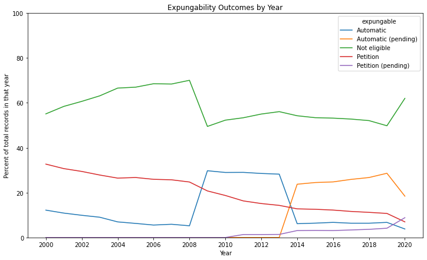

```python
lineplot = pd.melt(rowtable,
                  id_vars = ['year'],
                  value_vars = ['Automatic', 'Automatic (pending)',
                                'Not eligible', 'Petition', 'Petition (pending)'])

plt.figure(figsize=(12,7))
sns.lineplot(x='year', y='value', hue='expungable',data=lineplot)
plt.ylabel('Percent of total records in that year')
plt.xlabel('Year')
plt.title('Expungability Outcomes by Year')
plt.ylim(0,100)
plt.locator_params(axis="x", integer=True, tight=True, nbins=20)
```

## How do these counts break down by race?

Race is coded in the data, but in an inconsistent way:

```python
courtdata.stb.freq(['Race'])
```

|  | Race | count | percent | cumulative_count | cumulative_percent |
| --- | --- | --- | --- | --- | --- |
| 0 | White Caucasian(Non-Hispanic) | 3517348 | 38.847412 | 3517348 | 38.847412 |
| 1 | Black(Non-Hispanic) | 2501329 | 27.625972 | 6018677 | 66.473384 |
| 2 | White Caucasian (Non-Hispanic) | 1280318 | 14.140495 | 7298995 | 80.613879 |
| 3 | Black (Non-Hispanic) | 1006077 | 11.111635 | 8305072 | 91.725514 |
| 4 | Hispanic | 291017 | 3.214142 | 8596089 | 94.939656 |
| 5 | Other(Includes Not Applicable.. Unknown) | 109833 | 1.213052 | 8705922 | 96.152709 |
| 6 | White | 101797 | 1.124299 | 8807719 | 97.277007 |
| 7 | Asian Or Pacific Islander | 88771 | 0.980433 | 8896490 | 98.257440 |
| 8 | Black | 71787 | 0.792853 | 8968277 | 99.050293 |
| 9 | MISSING | 31319 | 0.345903 | 8999596 | 99.396196 |
| 10 | Unknown (Includes Not Applicable.. Unknown) | 24917 | 0.275196 | 9024513 | 99.671392 |
| 11 | Other (Includes Not Applicable.. Unknown) | 18524 | 0.204589 | 9043037 | 99.875981 |
| 12 | American Indian | 9034 | 0.099776 | 9052071 | 99.975757 |
| 13 | Unknown | 1605 | 0.017726 | 9053676 | 99.993484 |
| 14 | Asian or Pacific Islander | 491 | 0.005423 | 9054167 | 99.998907 |
| 15 | American Indian or Alaskan Native | 65 | 0.000718 | 9054232 | 99.999624 |
| 16 | American Indian Or Alaskan Native | 34 | 0.000376 | 9054266 | 100.000000 |

We have to combine and collapse these categories to get a clear picture of how expungability outcomes depend on race:

```python
replace_map = {'Black(Non-Hispanic)':'Black (Non-Hispanic)',
               'White Caucasian(Non-Hispanic)':'White (Non-Hispanic)',
               'Other(Includes Not Applicable.. Unknown)':'Other',
               'White Caucasian (Non-Hispanic)':'White (Non-Hispanic)',
               'Unknown (Includes Not Applicable.. Unknown)':'Other',
               'NA':'Other',
               'Asian Or Pacific Islander':'Asian or Pacific Islander',
               'Black (Non-Hispanic)':'Black (Non-Hispanic)',
               'White':'White (Non-Hispanic)',
               'American Indian':'American Indian or Alaskan Native',
               'Unknown':'Other',
               'Other (Includes Not Applicable.. Unknown)':'Other',
               'Black':'Black (Non-Hispanic)',
               'American Indian or Alaskan Native':'American Indian or Alaskan Native',
               'American Indian Or Alaskan Native':'American Indian or Alaskan Native',
               'Asian or Pacific Islander':'Asian or Pacific Islander'}
courtdata.Race = courtdata.Race.replace(replace_map)
```

```python
courtdata.stb.freq(['Race'])
```

|  | Race | count | percent | cumulative_count | cumulative_percent |
| --- | --- | --- | --- | --- | --- |
| 0 | White (Non-Hispanic) | 4899463 | 54.112205 | 4899463 | 54.112205 |
| 1 | Black (Non-Hispanic) | 3579193 | 39.530460 | 8478656 | 93.642665 |
| 2 | Hispanic | 291017 | 3.214142 | 8769673 | 96.856808 |
| 3 | Other | 154879 | 1.710564 | 8924552 | 98.567371 |
| 4 | Asian or Pacific Islander | 89262 | 0.985856 | 9013814 | 99.553227 |
| 5 | MISSING | 31319 | 0.345903 | 9045133 | 99.899130 |
| 6 | American Indian or Alaskan Native | 9133 | 0.100870 | 9054266 | 100.000000 |

We can now generate a cross-tabulation of race and expungability outcome. The following table contains row percents: of all records from a person of the given race, what percent falls within each expungability outcome?

```python
rowtable = (pd.crosstab(courtdata.Race, courtdata.expungable, normalize='index')*100).round(2).reset_index()
rowtable
```

| expungable | Race | Automatic | Automatic (pending) | Not eligible | Petition | Petition (pending) |
| --- | --- | --- | --- | --- | --- | --- |
| 0 | American Indian or Alaskan Native | 32.40 | 27.24 | 26.80 | 11.68 | 1.87 |
| 1 | Asian or Pacific Islander | 30.69 | 19.75 | 30.35 | 16.54 | 2.67 |
| 2 | Black (Non-Hispanic) | 11.70 | 8.96 | 61.23 | 16.56 | 1.55 |
| 3 | Hispanic | 29.88 | 27.48 | 31.17 | 10.24 | 1.23 |
| 4 | MISSING | 48.76 | 45.58 | 2.70 | 2.57 | 0.39 |
| 5 | Other | 25.36 | 31.78 | 29.01 | 11.73 | 2.12 |
| 6 | White (Non-Hispanic) | 17.99 | 11.40 | 52.26 | 16.21 | 2.13 |

We can plot these percents:

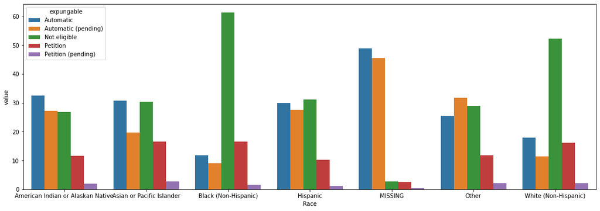

```python
barplot = pd.melt(rowtable,
                  id_vars = ['Race'],
                  value_vars = ['Automatic', 'Automatic (pending)',
                                'Not eligible', 'Petition', 'Petition (pending)'])

plt.figure(figsize=(18, 6))
sns.barplot(x='Race', y='value', hue='expungable', data=barplot)
```

## What are the most frequent reasons for each expungability outcome?

We can assess the most common reasons for each expungability decision:

```python
reasons = pd.DataFrame(courtdata.groupby(['expungable', 'reason']).size())
reasons = reasons.rename({0:'count'}, axis=1)

autoex = reasons.query("expungable == 'Automatic'")
autoex = autoex.assign(percent = round(100*(autoex['count'] / sum(autoex['count'])), 2))

autopend = reasons.query("expungable == 'Automatic (pending)'")
autopend = autopend.assign(percent = round(100*(autopend['count'] / sum(autopend['count'])), 2))

petex = reasons.query("expungable == 'Petition'")
petex = petex.assign(percent = round(100*(petex['count'] / sum(petex['count'])), 2))

petpend = reasons.query("expungable == 'Petition (pending)'")
petpend = petpend.assign(percent = round(100*(petpend['count'] / sum(petpend['count'])), 2))

notex = reasons.query("expungable == 'Not eligible'")
notex = notex.assign(percent = round(100*(notex['count'] / sum(notex['count'])), 2))
```

```python
autoex.sort_values('count', ascending=False)
```

| expungable | reason | count | percent |
| --- | --- | --- | --- |
| Automatic | Conviction of misdemeanor charges listed in 19.2-392.6 B with no convictions within 7 years from disposition date | 914798 | 62.13 |
|  | Dismissal of misdemeanor charges with no arrests or charges in the past 3 years and no convictions on the person's record | 557424 | 37.86 |
|  | Deferred dismissal of misdemeanor charges covered under 19.2-392.6-A | 180 | 0.01 |

```python
autopend.sort_values('count', ascending=False)
```

| expungable | reason | count | percent |
| --- | --- | --- | --- |
| Automatic (pending) | Conviction of misdemeanor charges listed in 19.2-392.6 B with no convictions since the disposition date. However, because the disposition date is within 7 years of the current date, the record is not … | 1042696 | 100.0 |

```python
petex.sort_values('count', ascending=False)
```

| expungable | reason | count | percent |
| --- | --- | --- | --- |
| Petition | Dismissal of misdemeanor charges, but with arrests or charges in the past 3 years | 423682 | 29.19 |
|  | Dismissal of felony charges | 412847 | 28.44 |
|  | Dismissal of misdemeanor charges with no arrests or charges in the past 3 years, but with convictions on the person's record | 325715 | 22.44 |
|  | Dismissal of misdemeanor charges with no arrests or charges in the past 3 years, but with prior convictions on the person's record | 98159 | 6.76 |
|  | Conviction or deferred dismissal of felony charges that are not ones listed under 19.2-392.12, with no felonies within the last 10 years, no class 3 or 4 felony conviction within the past 20 years, no… | 95532 | 6.58 |
|  | Conviction of misdemeanor charges listed in 19.2-392.6 B with no convictions within 7 years from disposition date | 66140 | 4.56 |
|  | Deferred dismissal of misdemeanor charges not covered under 19.2-392.6-A | 19315 | 1.33 |
|  | Dismissal of misdemeanor charges with no arrests or charges in the past 3 years and no convictions on the person's record | 6840 | 0.47 |
|  | Conviction of misdemeanor charges not listed in 19.2-392.6 A or B and not ineligible for expungement under 19.2-392.12, with no felonies within the last 10 years, no class 3 or 4 felony conviction wit… | 3392 | 0.23 |
|  | Dismissal of misdemeanor charges, but with convictions on the person's record | 51 | 0.00 |
|  | Deferred dismissal of misdemeanor charges covered under 19.2-392.6-A | 1 | 0.00 |

```python
petpend.sort_values('count', ascending=False)
```

| expungable | reason | count | percent |
| --- | --- | --- | --- |
| Petition (pending) | Conviction or deferred dismissal of felony charges that are not ones listed under 19.2-392.12, with no felonies within the last 10 years, no class 3 or 4 felony conviction within the past 20 years, no… | 93451 | 55.16 |
|  | Conviction of misdemeanor charges listed in 19.2-392.6 B with no convictions since the disposition date. However, because the disposition date is within 7 years of the current date, the record is not … | 74067 | 43.72 |
|  | Conviction of misdemeanor charges not listed in 19.2-392.6 A or B and not ineligible for expungement under 19.2-392.12, with no felonies within the last 10 years, no class 3 or 4 felony conviction wit… | 1911 | 1.13 |

```python
notex.sort_values('count', ascending=False)
```

| expungable | reason | count | percent |
| --- | --- | --- | --- |
| Not eligible | Conviction of misdemeanor charges that are not excluded from expungement by 19.2-392.12, but with convictions of another kind within 7 years from disposition date | 1205282 | 24.51 |
|  | Conviction or deferred dismissal of misdemeanor charges that are excluded from expungement by 19.2-392.12 | 1114690 | 22.67 |
|  | Conviction or deferred dismissal of felony charges, but with convictions within 10 years from disposition date | 644911 | 13.11 |
|  | Dismissal of felony charges; HOWEVER, the outcome is changed to not eligible because the lifetime limit of two expungements has been exceeded | 639084 | 12.99 |
|  | Dismissal of misdemeanor charges, but with arrests or charges in the past 3 years; HOWEVER, the outcome is changed to not eligible because the lifetime limit of two expungements has been exceeded | 580747 | 11.81 |
|  | Conviction or deferred dismissal of felony charges, but with a felony conviction within the last 10 years | 136923 | 2.78 |
|  | Conviction or deferred dismissal of felony charges, but with a prior conviction of a Class 1 or 2 felony or any other felony punishable by imprisonment for life | 95236 | 1.94 |
|  | Dismissal of misdemeanor charges with no arrests or charges in the past 3 years, but with convictions on the person's record; HOWEVER, the outcome is changed to not eligible because the lifetime limit… | 88370 | 1.80 |
|  | Conviction of misdemeanor charges listed in 19.2-392.6 B with no convictions since the disposition date. However, because the disposition date is within 7 years of the current date, the record is not … | 68580 | 1.39 |
|  | Conviction of misdemeanor charges listed in 19.2-392.6 B with no convictions within 7 years from disposition date; HOWEVER, the outcome is changed to not eligible because the lifetime limit of two exp… | 68477 | 1.39 |
|  | Conviction or deferred dismissal of felony charges that are ineligible for expungement under 19.2-392.12 | 58847 | 1.20 |
|  | Conviction or deferred dismissal of felony charges, but with a class 3 or 4 felony conviction within the past 20 years | 57841 | 1.18 |
|  | Conviction or deferred dismissal of felony charges that are not ones listed under 19.2-392.12, with no felonies within the last 10 years, no class 3 or 4 felony conviction within the past 20 years, no… | 47885 | 0.97 |
|  | Dismissal of misdemeanor charges with no arrests or charges in the past 3 years, but with prior convictions on the person's record; HOWEVER, the outcome is changed to not eligible because the lifetime… | 41568 | 0.85 |
|  | Dismissal of misdemeanor charges with no arrests or charges in the past 3 years and no convictions on the person's record; HOWEVER, the outcome is changed to not eligible because the lifetime limit of… | 29800 | 0.61 |
|  | Conviction or deferred dismissal of felony charges that are not ones listed under 19.2-392.12, with no felonies within the last 10 years, no class 3 or 4 felony conviction within the past 20 years, no… | 27441 | 0.56 |
|  | Conviction of misdemeanor charges not listed in 19.2-392.6 A or B and not ineligible for expungement under 19.2-392.12, but with felony convictions within the last 10 years | 5578 | 0.11 |
|  | Deferred dismissal of misdemeanor charges not covered under 19.2-392.6-A; HOWEVER, the outcome is changed to not eligible because the lifetime limit of two expungements has been exceeded | 3793 | 0.08 |
|  | Conviction of misdemeanor charges not listed in 19.2-392.6 A or B and not ineligible for expungement under 19.2-392.12, with no felonies within the last 10 years, no class 3 or 4 felony conviction wit… | 1420 | 0.03 |
|  | Conviction of misdemeanor charges not listed in 19.2-392.6 A or B and not ineligible for expungement under 19.2-392.12, with no felonies within the last 10 years, no class 3 or 4 felony conviction wit… | 896 | 0.02 |
|  | Conviction of misdemeanor charges not listed in 19.2-392.6 A or B and not ineligible for expungement under 19.2-392.12, but with a prior conviction for a class 3 or 4 felony within the past 20 years | 502 | 0.01 |
|  | Conviction of misdemeanor charges not listed in 19.2-392.6 A or B and not ineligible for expungement under 19.2-392.12, but with a prior conviction for a class 1 or 2 felony or another felony punishab… | 190 | 0.00 |
|  | Deferred dismissal of misdemeanor charges covered under 19.2-392.6-A; HOWEVER, the outcome is changed to not eligible because the lifetime limit of two expungements has been exceeded | 2 | 0.00 |
|  | Dismissal of misdemeanor charges, but with convictions on the person's record; HOWEVER, the outcome is changed to not eligible because the lifetime limit of two expungements has been exceeded | 2 | 0.00 |

## How do these reasons differ by race?

```python
reasons = pd.DataFrame(courtdata.groupby(['expungable', 'reason', 'Race']).size().unstack())
reasons = reasons.rename({0:'count'}, axis=1)
```

```python
autoex = reasons.query("expungable == 'Automatic'")
autoex = (100. * autoex / autoex.sum()).round(0)

autopend = reasons.query("expungable == 'Automatic (pending)'")
autopend = (100. * autopend / autopend.sum()).round(0)

petex = reasons.query("expungable == 'Petition'")
petex = (100. * petex / petex.sum()).round(0)

petpend = reasons.query("expungable == 'Petition (pending)'")
petpend = (100. * petpend / petpend.sum()).round(0)

notex = reasons.query("expungable == 'Not eligible'")
notex = (100. * notex / notex.sum()).round(0)
```

```python
autoex.sort_values('White (Non-Hispanic)', ascending=False)
```

| expungable | Race reason | American Indian or Alaskan Native | Asian or Pacific Islander | Black (Non-Hispanic) | Hispanic | MISSING | Other | White (Non-Hispanic) |
| --- | --- | --- | --- | --- | --- | --- | --- | --- |
| Automatic | Conviction of misdemeanor charges listed in 19.2-392.6 B with no convictions within 7 years from disposition date | 70.0 | 59.0 | 63.0 | 82.0 | 59.0 | 65.0 | 60.0 |
|  | Dismissal of misdemeanor charges with no arrests or charges in the past 3 years and no convictions on the person's record | 30.0 | 41.0 | 37.0 | 18.0 | 41.0 | 35.0 | 40.0 |
|  | Deferred dismissal of misdemeanor charges covered under 19.2-392.6-A | NaN | NaN | 0.0 | 0.0 | NaN | 0.0 | 0.0 |

```python
autopend.sort_values('White (Non-Hispanic)', ascending=False)
```

| expungable | Race reason | American Indian or Alaskan Native | Asian or Pacific Islander | Black (Non-Hispanic) | Hispanic | MISSING | Other | White (Non-Hispanic) |
| --- | --- | --- | --- | --- | --- | --- | --- | --- |
| Automatic (pending) | Conviction of misdemeanor charges listed in 19.2-392.6 B with no convictions since the disposition date. However, because the disposition date is within 7 years of the current date, the record is not … | 100.0 | 100.0 | 100.0 | 100.0 | 100.0 | 100.0 | 100.0 |

```python
petex.sort_values('White (Non-Hispanic)', ascending=False)
```

| expungable | Race reason | American Indian or Alaskan Native | Asian or Pacific Islander | Black (Non-Hispanic) | Hispanic | MISSING | Other | White (Non-Hispanic) |
| --- | --- | --- | --- | --- | --- | --- | --- | --- |
| Petition | Dismissal of misdemeanor charges, but with arrests or charges in the past 3 years | 24.0 | 27.0 | 29.0 | 28.0 | 14.0 | 30.0 | 29.0 |
|  | Dismissal of felony charges | 22.0 | 25.0 | 32.0 | 13.0 | 18.0 | 24.0 | 26.0 |
|  | Dismissal of misdemeanor charges with no arrests or charges in the past 3 years, but with convictions on the person's record | 29.0 | 30.0 | 20.0 | 34.0 | 33.0 | 30.0 | 24.0 |
|  | Conviction or deferred dismissal of felony charges that are not ones listed under 19.2-392.12, with no felonies within the last 10 years, no class 3 or 4 felony conviction within the past 20 years, no… | 8.0 | 5.0 | 7.0 | 9.0 | 13.0 | 3.0 | 7.0 |
|  | Dismissal of misdemeanor charges with no arrests or charges in the past 3 years, but with prior convictions on the person's record | 5.0 | 4.0 | 7.0 | 3.0 | 1.0 | 5.0 | 7.0 |
|  | Conviction of misdemeanor charges listed in 19.2-392.6 B with no convictions within 7 years from disposition date | 8.0 | 6.0 | 3.0 | 10.0 | 14.0 | 6.0 | 5.0 |
|  | Deferred dismissal of misdemeanor charges not covered under 19.2-392.6-A | 2.0 | 2.0 | 1.0 | 3.0 | 7.0 | 2.0 | 1.0 |
|  | Dismissal of misdemeanor charges with no arrests or charges in the past 3 years and no convictions on the person's record | 1.0 | 1.0 | 0.0 | 1.0 | 0.0 | 1.0 | 1.0 |
|  | Conviction of misdemeanor charges not listed in 19.2-392.6 A or B and not ineligible for expungement under 19.2-392.12, with no felonies within the last 10 years, no class 3 or 4 felony conviction wit… | 0.0 | 0.0 | 0.0 | 0.0 | 0.0 | 0.0 | 0.0 |
|  | Deferred dismissal of misdemeanor charges covered under 19.2-392.6-A | NaN | NaN | NaN | NaN | NaN | NaN | 0.0 |
|  | Dismissal of misdemeanor charges, but with convictions on the person's record | NaN | NaN | 0.0 | 0.0 | NaN | NaN | 0.0 |

```python
petpend.sort_values('White (Non-Hispanic)', ascending=False)
```

[output not shown]

```python
notex.sort_values('White (Non-Hispanic)', ascending=False)
```

[output not shown]